# ej-analisis_textual

Romina De León

21/7/2021

## Comenzando con análisis textual en R Studio

Durante esta ejercitación utilizaremos todo lo visto en las unidades previas. En primer lugar, nos ubicaremos dentro de nuestra carpeta, donde se encuentran los archivos de nuestro corpus. Vale aclarar, que les he dejado más de 40 textos, que son discursos y Decretos de Necesidad de Urgencia, que se realizaron desde el inicio del Distanciamiento Social, Preventivo y Obligatorio el 13 de marzo, hasta el 30 de junio de 2020, han sido nombrados:mes-dia-dnu o disc. Asimismo, este ejercicio, lo he realizado con los primeros cuatro archivos, 0313disc.txt; 0316dnu.txt; 0318dnu.txt y 0320disc.txt

```r
getwd()
```

```
## [1] "C:/hdcaicyt/R/discurso/prueba1"
```

```r
#Deben modificar su ubicación

setwd("C:/hdcaicyt/R/discurso/prueba1")
```

Luego instalaremos y llamaremos a las librerías que utilizaremos

```r
suppressPackageStartupMessages({

 library(stopwords)
library(tidytext)
library(tidyverse)
library(tm)
library(stringr)
library(dplyr)
library(ggplot2)

})
```

Ahora chequearemos que están en dicha carpeta los archivos con los que trabajaremos

```r
list.files('C:/hdcaicyt/R/discurso/prueba1/')
```

[output not shown]

A continuación, haremos una nueva lista con los elementos de texto plano que se encuentren en la carpeta, para ello, utilizaremos la función `list.files` y aclararemos que tipo de archivo, y que debe contener.

```r
archivos <- list.files("./", pattern = "\\.txt$", full.names = TRUE)

# Podemos llamar a la lista creada, considerar que tipo de elemento y su tamaño.

archivos
```

```
## [1] "./0313disc.txt" "./0316dnu.txt"  "./0318dnu.txt"  "./0320disc.txt"
```

```r
class(archivos)
```

```
## [1] "character"
```

```r
length(archivos)
```

```
## [1] 4
```

Posteriormente para facilitar nuestro trabajo, eliminaremos lo que no es necesario del nombre

```r
textos_archivo <- gsub("\\.txt", "", archivos, perl = TRUE)

#La función gsub es una función para la limpieza de datos, con ello eliminaremos la extensión de cada elemento dentro de la lista.

textos_archivo
```

```
## [1] "./0313disc" "./0316dnu"  "./0318dnu"  "./0320disc"
```

```r
#También eliminaré './' que quedaron dentro de mi lista

textos_archivo <- gsub("./", "", textos_archivo, perl = TRUE)

textos_archivo
```

```
## [1] "0313disc" "0316dnu"  "0318dnu"  "0320disc"
```

Para poder continuar con el análisis de nuestro corpus armaremos un tibble, que es otro tipo de lista, como el dataframe.

```r
mensajes <- tibble(textos_archivo = character(),
                   parrafo = numeric(),
                   texto = character())

#Luego de tibble, hemos indicado que será cada columna y que tiene de elementos contendrá

mensajes
```

```
## # A tibble: 0 x 3
## # ... with 3 variables: textos_archivo <chr>, parrafo <dbl>, texto <chr>
```

```r
#Nos figura que nuestra tibble se encuentra vacía, por ello a continuación la completaremos con nuestros datos.
```

Para secuenciar el corpus, realizaremos una iteración con la función `for`, en la que indicaremos que tome cada uno de los elementos de `archivos`, lea cada elemento, los separe, y complete el tibble que creamos en el paso anterior.

```r
#secuenciamos nuestro corpus

for (i in 1:length(archivos)){
  discurso <- read_lines(paste("C:/hdcaicyt/R/discurso/prueba1/",
                               archivos[i],
                               sep = "/"))
  temporal <- tibble(textos_archivo = textos_archivo[i],
                     parrafo = seq_along(discurso),
                     texto = discurso)
  mensajes <- bind_rows(mensajes, temporal)
}

temporal
```

```
## # A tibble: 23 x 3
##    textos_archivo parrafo texto
##    <chr>            <int> <chr>
##  1 0320disc             1 Palabras del presidente de la Nación, Alberto Fernánd~
##  2 0320disc             2 Viernes 20 de marzo de 2020
##  3 0320disc             3 Palabras del presidente de la Nación, Alberto Fernánd~
##  4 0320disc             4 PRESIDENTE.- Buenas noches a todos y a todas: gracias~
##  5 0320disc             5 La verdad que el cuidado de la salud de los argentino~
##  6 0320disc             6 En estos días dictamos más de 30 medidas de todo tipo~
##  7 0320disc             7 La verdad es que hicimos muchos esfuerzos porque la g~
##  8 0320disc             8 Por ese motivo acabamos – después de tener una larga ~
##  9 0320disc             9 Esto quiere decir que – a partir de ese momento – nad~
## 10 0320disc            10 Esta medida, la hemos dictado, ahora, tratando de que~
## # ... with 13 more rows
```

```r
mensajes
```

```
## # A tibble: 137 x 3
##    textos_archivo parrafo texto
##    <chr>            <dbl> <chr>
##  1 0313disc             1 Mensaje por Cadena Nacional del presidente Alberto Fe~
##  2 0313disc             2 Viernes 13 de marzo de 2020
##  3 0313disc             3 Querido pueblo argentino,
##  4 0313disc             4 Voy a compartir con ustedes información importante so~
##  5 0313disc             5 Ayer la ORGANIZACIÓN MUNDIAL DE LA SALUD (OMS), decla~
##  6 0313disc             6 Quiero que sepan qué es lo que estamos haciendo para ~
##  7 0313disc             7 En situaciones de alarma generalizada es imprescindib~
##  8 0313disc             8 Un Estado presente en materia de salud es la mejor ma~
##  9 0313disc             9 La realidad es que esta pandemia nos convoca como soc~
## 10 0313disc            10 Nos convoca al Estado Nacional, a cada provincia, a c~
## # ... with 127 more rows
```

Una vez que hemos completado el tibble, procederemos con la tokenización de nuestro corpus, es decir extraeremos sus unidades de análisis.

```r
mensajes_palabras <- mensajes %>%
  unnest_tokens(palabra, texto)


mensajes_palabras
```

```
## # A tibble: 5,109 x 3
##    textos_archivo parrafo palabra
##    <chr>            <dbl> <chr>
##  1 0313disc             1 mensaje
##  2 0313disc             1 por
##  3 0313disc             1 cadena
##  4 0313disc             1 nacional
##  5 0313disc             1 del
##  6 0313disc             1 presidente
##  7 0313disc             1 alberto
##  8 0313disc             1 fernández
##  9 0313disc             1 ante
## 10 0313disc             1 la
## # ... with 5,099 more rows
```

Como podemos observar se encuentran palabras que no son necesarias y hacen que nuestro corpus extenso, para ello eliminaremos las stopwords.

```r
#primero instalaremos el paquete de stopwords, eliminamos las palabras vacías, con la función filter y agregando que estamos trabajando en español.

stopwords1 <- get_stopwords("es")

stopwords1
```

```
## # A tibble: 308 x 2
##    word  lexicon
##    <chr> <chr>
##  1 de    snowball
##  2 la    snowball
##  3 que   snowball
##  4 el    snowball
##  5 en    snowball
##  6 y     snowball
##  7 a     snowball
##  8 los   snowball
##  9 del   snowball
## 10 se    snowball
## # ... with 298 more rows
```

```r
#Nos ha armado otro tibble con las palabras vacías

#Para que pueda limpiar nuestra tibble, debemos renombrar, la columna word por "palabra"

stopwords1 <- stopwords1 %>%
rename(palabra = word)

stopwords1
```

```
## # A tibble: 308 x 2
##    palabra lexicon
##    <chr>   <chr>
##  1 de      snowball
##  2 la      snowball
##  3 que     snowball
##  4 el      snowball
##  5 en      snowball
##  6 y       snowball
##  7 a       snowball
##  8 los     snowball
##  9 del     snowball
## 10 se      snowball
## # ... with 298 more rows
```

Importante, para cambiar nombres primero debes poner el nuevo término y a continuación el que deseas cambiar.

```r
mensajes_limpio <- mensajes_palabras %>%
anti_join(stopwords1)
#El mensaje que nos aparece, es porque ambas tibble tiene la misma variable común "palabra", si no la encontrase devolvería error.
```

```r
#Aquí eliminaremos los dígitos, pues no influyen en nuestro análisis


mensajes_limpio <- mensajes_limpio %>%
mutate(palabra = str_remove(palabra, "\\d+"))

# NIDIA
# acá traté de limpiar los NA que me quedaban luego de eliminar los números pero o me salta error o no cambia nada! :(

mensajes_limpio
```

```
## # A tibble: 2,784 x 3
##    textos_archivo parrafo palabra
##    <chr>            <dbl> <chr>
##  1 0313disc             1 "mensaje"
##  2 0313disc             1 "cadena"
##  3 0313disc             1 "nacional"
##  4 0313disc             1 "presidente"
##  5 0313disc             1 "alberto"
##  6 0313disc             1 "fernández"
##  7 0313disc             1 "emergencia"
##  8 0313disc             1 "coronavirus"
##  9 0313disc             2 "viernes"
## 10 0313disc             2 ""
## # ... with 2,774 more rows
```

Una vez que hemos limpiado y tokenizado nuestro corpus, procederemos a realizar análisis de frecuencia y gráficos

```r
#Con estas líneas podremos observar palabras y sus frecuencias absolutas

mensajes_palabras %>%
  count(palabra, sort = TRUE)
```

```
## # A tibble: 1,343 x 2
##    palabra     n
##    <chr>   <int>
##  1 de        343
##  2 la        208
##  3 que       191
##  4 el        156
##  5 a         147
##  6 y         142
##  7 en        129
##  8 los        93
##  9 del        72
## 10 las        61
## # ... with 1,333 more rows
```

```r
mensajes_limpio %>%
  count(palabra, sort = TRUE)
```

```
## # A tibble: 1,152 x 2
##    palabra        n
##    <chr>      <int>
##  1 ""           278
##  2 "decreto"     50
##  3 "artículo"    37
##  4 "n"           31
##  5 "nacional"    31
##  6 "art"         26
##  7 "b.o"         26
##  8 "nº"          21
##  9 "personas"    20
## 10 "pandemia"    17
## # ... with 1,142 more rows
```

```r
#Ahora comenzaremos con los análisis del corpus que no fue limpiado

nrow(mensajes_palabras) / length(archivos)
```

```
## [1] 1277.25
```

```r
#En la línea anterior hemos calculado el promedio de palabras por discurso o dnu.

#Con la próxima instrucción calcularemos la frecuencia relativa por palabras y adjudicaremos ese nuevo valor en una columna que se denominará 'relativa'. Por lo cual tendremos tres columnas, la del término, su frecuencia absoluta y la relativa.

mensajes_palabras %>% count (palabra, sort = TRUE) %>% mutate (relativa = n / sum(n))
```

```
## # A tibble: 1,343 x 3
##    palabra     n relativa
##    <chr>   <int>    <dbl>
##  1 de        343   0.0671
##  2 la        208   0.0407
##  3 que       191   0.0374
##  4 el        156   0.0305
##  5 a         147   0.0288
##  6 y         142   0.0278
##  7 en        129   0.0252
##  8 los        93   0.0182
##  9 del        72   0.0141
## 10 las        61   0.0119
## # ... with 1,333 more rows
```

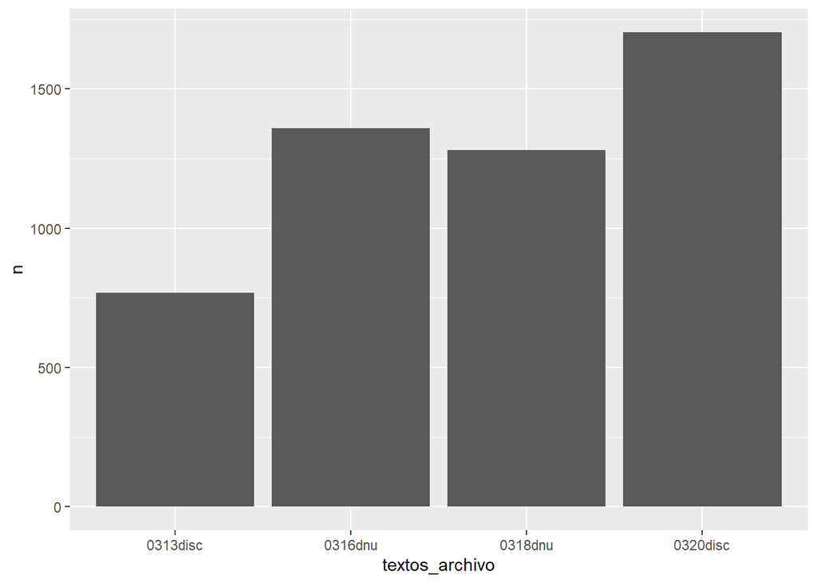

```r
 # Para poder almacenar estos datos crearemos una nueva tabla denominada 'mensajes_frecuencias'.

mensajes_frecuencias <- mensajes_palabras %>%
           count(palabra, sort = TRUE) %>%
           mutate(relative = n / sum(n))

#Si quisieramos que nos devuelva la frecuencia por cada discurso o dnu, debemos agrupar por cada uno de ello, lo realizamos con la función 'group_by' y lo guardamos en otra tabla llamada 'frecuencia_text_arch'

frecuencia_text_arch <- mensajes_palabras %>%
           group_by(textos_archivo) %>%
           count(palabra, sort = T) %>%
           mutate(relative = n / sum(n)) %>%
           ungroup()

#Para finalizar podemos graficar todas estas mediciones

mensajes_palabras %>%
           group_by(textos_archivo) %>%
          count(palabra, sort = T) %>%
           ggplot() +
           geom_bar(aes(textos_archivo,
                        n),
                    stat = 'identity')
```

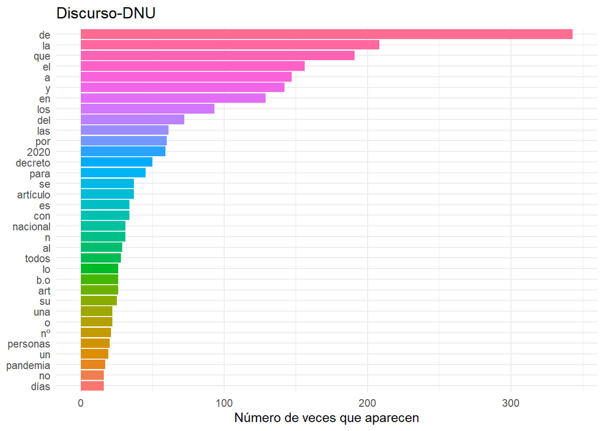

```r
# Ahora graficaremos las palabras más frecuentes de discursos y dnu, para ello primero llamaremos a nuestra tabla 'mensajes_palabras' luego le diremos que cuente las ocurrencias, ordenadas de mayor a menor, en la tercera línea indicamos que filtre las ocurrencias mayores a 15. Como explicamos antes, como se crea una nueva tabla interna debemos indicar con mutate, la nueva columna, que almacenará los nuevos datos. Luego daremos las indicaciones para graficar con la función 'ggplot'. Primera aclaración, esta función une sus líneas con '+'; el argumento fill hará que cada palabra tenga un color determinado, 'stat' indica que las barras tomaran la altura según 'n'. Las líneas siguientes indicaran título, donde se ubicará la leyenda, y etiquetas en los ejes; y con 'coord_flip()' nos aseguramos que el eje 'Y' se imprima de forma horizontal.

mensajes_palabras %>%
count(palabra, sort = T) %>%
filter(n > 15) %>%
mutate(palabra = reorder(palabra, n)) %>%
ggplot(aes(x = palabra, y = n, fill = palabra)) +
geom_bar(stat="identity") +
theme_minimal() +
theme(legend.position = "none") +
ylab("Número de veces que aparecen") +
xlab(NULL) +
ggtitle("Discurso-DNU") +
coord_flip()
```

Ahora, te propongo que realices los análisis y gráficos anteriores para `mensajes_limpio` y compares los resultados.